# Risk_Analysis -1

```python
import pandas as pd
import numpy as np
import matplotlib.pyplot as plt
import seaborn as sns
import missingno as msno
import os
import warnings
warnings.simplefilter(action='ignore')
%matplotlib inline
```

```python
os.chdir("D:\Lohith\DA\Handson\Risk_Analytics")
```

```python
Client_Data = pd.read_csv("application_data.csv")   #Reading the Client data
Description = pd.read_csv(r"columns_description.csv",encoding='cp1252')
```

##### By Default it will show only 20 columns,Since we have more then 20 column, this function is used

```python
pd.set_option("display.max_columns",None,"display.max_rows",None)
```

```python
Description.drop(columns="Unnamed: 0", axis =1, inplace = True)  # Description of our Columns
Description[:122]
```

|  | Table | Row | Description | Special |
| --- | --- | --- | --- | --- |
| 0 | application_data | SK_ID_CURR | ID of loan in our sample | NaN |
| 1 | application_data | TARGET | Target variable (1 - client with payment diffi... | NaN |
| 2 | application_data | NAME_CONTRACT_TYPE | Identification if loan is cash or revolving | NaN |
| 3 | application_data | CODE_GENDER | Gender of the client | NaN |
| 4 | application_data | FLAG_OWN_CAR | Flag if the client owns a car | NaN |
| 5 | application_data | FLAG_OWN_REALTY | Flag if client owns a house or flat | NaN |
| 6 | application_data | CNT_CHILDREN | Number of children the client has | NaN |
| 7 | application_data | AMT_INCOME_TOTAL | Income of the client | NaN |
| 8 | application_data | AMT_CREDIT | Credit amount of the loan | NaN |
| 9 | application_data | AMT_ANNUITY | Loan annuity | NaN |
| 10 | application_data | AMT_GOODS_PRICE | For consumer loans it is the price of the good... | NaN |
| 11 | application_data | NAME_TYPE_SUITE | Who was accompanying client when he was applyi... | NaN |
| 12 | application_data | NAME_INCOME_TYPE | Clients income type (businessman, working, mat... | NaN |
| 13 | application_data | NAME_EDUCATION_TYPE | Level of highest education the client achieved | NaN |
| 14 | application_data | NAME_FAMILY_STATUS | Family status of the client | NaN |
| 15 | application_data | NAME_HOUSING_TYPE | What is the housing situation of the client (r... | NaN |
| 16 | application_data | REGION_POPULATION_RELATIVE | Normalized population of region where client l... | normalized |
| 17 | application_data | DAYS_BIRTH | Client's age in days at the time of application | time only relative to the application |
| 18 | application_data | DAYS_EMPLOYED | How many days before the application the perso... | time only relative to the application |
| 19 | application_data | DAYS_REGISTRATION | How many days before the application did clien... | time only relative to the application |
| 20 | application_data | DAYS_ID_PUBLISH | How many days before the application did clien... | time only relative to the application |
| 21 | application_data | OWN_CAR_AGE | Age of client's car | NaN |
| 22 | application_data | FLAG_MOBIL | Did client provide mobile phone (1=YES, 0=NO) | NaN |
| 23 | application_data | FLAG_EMP_PHONE | Did client provide work phone (1=YES, 0=NO) | NaN |
| 24 | application_data | FLAG_WORK_PHONE | Did client provide home phone (1=YES, 0=NO) | NaN |
| 25 | application_data | FLAG_CONT_MOBILE | Was mobile phone reachable (1=YES, 0=NO) | NaN |
| 26 | application_data | FLAG_PHONE | Did client provide home phone (1=YES, 0=NO) | NaN |
| 27 | application_data | FLAG_EMAIL | Did client provide email (1=YES, 0=NO) | NaN |
| 28 | application_data | OCCUPATION_TYPE | What kind of occupation does the client have | NaN |
| 29 | application_data | CNT_FAM_MEMBERS | How many family members does client have | NaN |

[output cut: 92 more lines]

```python
Client_Data.head(5) # Checking the top 5 records
```

|  | SK_ID_CURR | TARGET | NAME_CONTRACT_TYPE | CODE_GENDER | FLAG_OWN_CAR | FLAG_OWN_REALTY | CNT_CHILDREN | AMT_INCOME_TOTAL | AMT_CREDIT | AMT_ANNUITY | AMT_GOODS_PRICE | NAME_TYPE_SUITE | NAME_INCOME_TYPE | NAME_EDUCATION_TYPE | NAME_FAMILY_STATUS | NAME_HOUSING_TYPE | REGION_POPULATION_RELATIVE | DAYS_BIRTH | DAYS_EMPLOYED | DAYS_REGISTRATION | DAYS_ID_PUBLISH | OWN_CAR_AGE | FLAG_MOBIL | FLAG_EMP_PHONE | FLAG_WORK_PHONE | FLAG_CONT_MOBILE | FLAG_PHONE | FLAG_EMAIL | OCCUPATION_TYPE | … |
| --- | --- | --- | --- | --- | --- | --- | --- | --- | --- | --- | --- | --- | --- | --- | --- | --- | --- | --- | --- | --- | --- | --- | --- | --- | --- | --- | --- | --- | --- | --- |
| 0 | 100002 | 1 | Cash loans | M | N | Y | 0 | 202500.0 | 406597.5 | 24700.5 | 351000.0 | Unaccompanied | Working | Secondary / secondary special | Single / not married | House / apartment | 0.018801 | -9461 | -637 | -3648.0 | -2120 | NaN | 1 | 1 | 0 | 1 | 1 | 0 | Laborers | … |
| 1 | 100003 | 0 | Cash loans | F | N | N | 0 | 270000.0 | 1293502.5 | 35698.5 | 1129500.0 | Family | State servant | Higher education | Married | House / apartment | 0.003541 | -16765 | -1188 | -1186.0 | -291 | NaN | 1 | 1 | 0 | 1 | 1 | 0 | Core staff | … |
| 2 | 100004 | 0 | Revolving loans | M | Y | Y | 0 | 67500.0 | 135000.0 | 6750.0 | 135000.0 | Unaccompanied | Working | Secondary / secondary special | Single / not married | House / apartment | 0.010032 | -19046 | -225 | -4260.0 | -2531 | 26.0 | 1 | 1 | 1 | 1 | 1 | 0 | Laborers | … |
| 3 | 100006 | 0 | Cash loans | F | N | Y | 0 | 135000.0 | 312682.5 | 29686.5 | 297000.0 | Unaccompanied | Working | Secondary / secondary special | Civil marriage | House / apartment | 0.008019 | -19005 | -3039 | -9833.0 | -2437 | NaN | 1 | 1 | 0 | 1 | 0 | 0 | Laborers | … |
| 4 | 100007 | 0 | Cash loans | M | N | Y | 0 | 121500.0 | 513000.0 | 21865.5 | 513000.0 | Unaccompanied | Working | Secondary / secondary special | Single / not married | House / apartment | 0.028663 | -19932 | -3038 | -4311.0 | -3458 | NaN | 1 | 1 | 0 | 1 | 0 | 0 | Core staff | … |

```python
print("Client_Data: ",Client_Data.shape)
```

```
Client_Data:  (307511, 122)
```

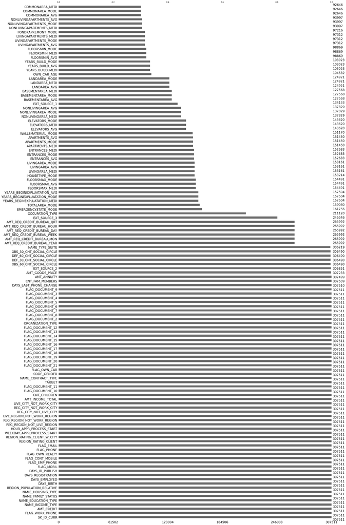

```python
msno.bar(Client_Data,sort = "descending")
```

```python
Client_Data.drop(Client_Data.columns[41:91],axis = 1, inplace =True)
```

```python
Client_Data.drop(columns=["DAYS_REGISTRATION","REGION_POPULATION_RELATIVE","FLAG_PHONE","REG_REGION_NOT_LIVE_REGION","REG_REGION_NOT_WORK_REGION","LIVE_REGION_NOT_WORK_REGION","OCCUPATION_TYPE","AMT_REQ_CREDIT_BUREAU_HOUR","AMT_REQ_CREDIT_BUREAU_DAY","AMT_REQ_CREDIT_BUREAU_WEEK","AMT_REQ_CREDIT_BUREAU_MON","AMT_REQ_CREDIT_BUREAU_QRT","AMT_REQ_CREDIT_BUREAU_YEAR"],axis =1, inplace =True)
```

```python
Client_Data.dropna(thresh=round(len(Client_Data)*0.4),axis=1,inplace =True)
```

###### The reason for dropping columns is few are redundant and few has missing values more than 60 %

- In few columns we can infer data by comparing with with other columns,"OCCUPATION_TYPE" can be filled by comparing data at "NAME_INCOME_TYPE".
- But as we can get insights directly from "NAME_INCOME_TYPE" which is higly depedant,we have dropped "OCCUPATION_TYPE".

```python
print("Client_Data: ",Client_Data.shape)
```

```
Client_Data:  (307511, 58)
```

```python
Client_Data.isnull().sum()
```

```
SK_ID_CURR                        0
TARGET                            0
NAME_CONTRACT_TYPE                0
CODE_GENDER                       0
FLAG_OWN_CAR                      0
FLAG_OWN_REALTY                   0
CNT_CHILDREN                      0
AMT_INCOME_TOTAL                  0
AMT_CREDIT                        0
AMT_ANNUITY                      12
AMT_GOODS_PRICE                 278
NAME_TYPE_SUITE                1292
NAME_INCOME_TYPE                  0
NAME_EDUCATION_TYPE               0
NAME_FAMILY_STATUS                0
NAME_HOUSING_TYPE                 0
DAYS_BIRTH                        0
DAYS_EMPLOYED                     0
DAYS_ID_PUBLISH                   0
FLAG_MOBIL                        0
FLAG_EMP_PHONE                    0
FLAG_WORK_PHONE                   0
FLAG_CONT_MOBILE                  0
FLAG_EMAIL                        0
CNT_FAM_MEMBERS                   2
REGION_RATING_CLIENT              0
REGION_RATING_CLIENT_W_CITY       0
WEEKDAY_APPR_PROCESS_START        0
HOUR_APPR_PROCESS_START           0
REG_CITY_NOT_LIVE_CITY            0
REG_CITY_NOT_WORK_CITY            0
LIVE_CITY_NOT_WORK_CITY           0
ORGANIZATION_TYPE                 0
OBS_30_CNT_SOCIAL_CIRCLE       1021
DEF_30_CNT_SOCIAL_CIRCLE       1021
OBS_60_CNT_SOCIAL_CIRCLE       1021
DEF_60_CNT_SOCIAL_CIRCLE       1021
DAYS_LAST_PHONE_CHANGE            1
FLAG_DOCUMENT_2                   0
FLAG_DOCUMENT_3                   0
FLAG_DOCUMENT_4                   0
FLAG_DOCUMENT_5                   0
FLAG_DOCUMENT_6                   0
FLAG_DOCUMENT_7                   0
FLAG_DOCUMENT_8                   0
FLAG_DOCUMENT_9                   0
FLAG_DOCUMENT_10                  0
FLAG_DOCUMENT_11                  0
FLAG_DOCUMENT_12                  0
FLAG_DOCUMENT_13                  0
FLAG_DOCUMENT_14                  0
FLAG_DOCUMENT_15                  0
FLAG_DOCUMENT_16                  0
FLAG_DOCUMENT_17                  0
FLAG_DOCUMENT_18                  0
FLAG_DOCUMENT_19                  0
FLAG_DOCUMENT_20                  0
FLAG_DOCUMENT_21                  0
dtype: int64
```

```python
Client_Data.dropna(how ="any",inplace =True)
```

```python
Client_Data.shape
```

```
(305185, 58)
```

```python
Client_Data.dtypes
```

```
SK_ID_CURR                       int64
TARGET                           int64
NAME_CONTRACT_TYPE              object
CODE_GENDER                     object
FLAG_OWN_CAR                    object
FLAG_OWN_REALTY                 object
CNT_CHILDREN                     int64
AMT_INCOME_TOTAL               float64
AMT_CREDIT                     float64
AMT_ANNUITY                    float64
AMT_GOODS_PRICE                float64
NAME_TYPE_SUITE                 object
NAME_INCOME_TYPE                object
NAME_EDUCATION_TYPE             object
NAME_FAMILY_STATUS              object
NAME_HOUSING_TYPE               object
DAYS_BIRTH                       int64
DAYS_EMPLOYED                    int64
DAYS_ID_PUBLISH                  int64
FLAG_MOBIL                       int64
FLAG_EMP_PHONE                   int64
FLAG_WORK_PHONE                  int64
FLAG_CONT_MOBILE                 int64
FLAG_EMAIL                       int64
CNT_FAM_MEMBERS                float64
REGION_RATING_CLIENT             int64
REGION_RATING_CLIENT_W_CITY      int64
WEEKDAY_APPR_PROCESS_START      object
HOUR_APPR_PROCESS_START          int64
REG_CITY_NOT_LIVE_CITY           int64
REG_CITY_NOT_WORK_CITY           int64
LIVE_CITY_NOT_WORK_CITY          int64
ORGANIZATION_TYPE               object
OBS_30_CNT_SOCIAL_CIRCLE       float64
DEF_30_CNT_SOCIAL_CIRCLE       float64
OBS_60_CNT_SOCIAL_CIRCLE       float64
DEF_60_CNT_SOCIAL_CIRCLE       float64
DAYS_LAST_PHONE_CHANGE         float64
FLAG_DOCUMENT_2                  int64
FLAG_DOCUMENT_3                  int64
FLAG_DOCUMENT_4                  int64
FLAG_DOCUMENT_5                  int64
FLAG_DOCUMENT_6                  int64
FLAG_DOCUMENT_7                  int64
FLAG_DOCUMENT_8                  int64
FLAG_DOCUMENT_9                  int64
FLAG_DOCUMENT_10                 int64
FLAG_DOCUMENT_11                 int64
FLAG_DOCUMENT_12                 int64
FLAG_DOCUMENT_13                 int64
FLAG_DOCUMENT_14                 int64
FLAG_DOCUMENT_15                 int64
FLAG_DOCUMENT_16                 int64
FLAG_DOCUMENT_17                 int64
FLAG_DOCUMENT_18                 int64
FLAG_DOCUMENT_19                 int64
FLAG_DOCUMENT_20                 int64
FLAG_DOCUMENT_21                 int64
dtype: object
```

###### Converting the below columns to Absolute values

```python
Client_Data["CODE_GENDER"]=Client_Data["CODE_GENDER"].replace("XNA","Others")
Client_Data["DAYS_LAST_PHONE_CHANGE"] = Client_Data["DAYS_LAST_PHONE_CHANGE"].abs()
Client_Data["DAYS_BIRTH"] = Client_Data["DAYS_BIRTH"].abs()
Client_Data["DAYS_EMPLOYED"] = Client_Data["DAYS_EMPLOYED"].abs()
Client_Data["DAYS_ID_PUBLISH"] = Client_Data["DAYS_ID_PUBLISH"].abs()
Client_Data["AMT_INCOME_TOTAL"] = Client_Data["AMT_INCOME_TOTAL"].abs()
Client_Data["AMT_CREDIT"] = Client_Data["AMT_CREDIT"].abs()
Client_Data["AMT_ANNUITY"] = Client_Data["AMT_ANNUITY"].abs()
Client_Data["AMT_GOODS_PRICE"] = Client_Data["AMT_GOODS_PRICE"].abs()
```

```python
Client_Data[["CODE_GENDER","DAYS_LAST_PHONE_CHANGE","DAYS_BIRTH","DAYS_EMPLOYED","DAYS_ID_PUBLISH","AMT_INCOME_TOTAL"]].head(5)
```

|  | CODE_GENDER | DAYS_LAST_PHONE_CHANGE | DAYS_BIRTH | DAYS_EMPLOYED | DAYS_ID_PUBLISH | AMT_INCOME_TOTAL |
| --- | --- | --- | --- | --- | --- | --- |
| 0 | M | 1134.0 | 9461 | 637 | 2120 | 202500.0 |
| 1 | F | 828.0 | 16765 | 1188 | 291 | 270000.0 |
| 2 | M | 815.0 | 19046 | 225 | 2531 | 67500.0 |
| 3 | F | 617.0 | 19005 | 3039 | 2437 | 135000.0 |
| 4 | M | 1106.0 | 19932 | 3038 | 3458 | 121500.0 |

###### Converting number of Days to Years

```python
Client_Data.insert(loc=12,column="Age",value=(Client_Data[["DAYS_BIRTH"]]/365.25).astype(int))
Client_Data["DAYS_EMPLOYED"] = round(Client_Data[["DAYS_EMPLOYED"]]/365.25,1)
Client_Data["DAYS_ID_PUBLISH"] = round(Client_Data[["DAYS_ID_PUBLISH"]]/365.25,1)
Client_Data.drop("DAYS_BIRTH",axis =1,inplace= True)
```

```python
Client_Data[["Age","DAYS_EMPLOYED","DAYS_ID_PUBLISH"]].describe()
```

|  | Age | DAYS_EMPLOYED | DAYS_ID_PUBLISH |
| --- | --- | --- | --- |
| count | 305185.000000 | 305185.000000 | 305185.000000 |
| mean | 43.417825 | 185.592190 | 8.198860 |
| std | 11.941714 | 381.919921 | 4.132549 |
| min | 20.000000 | 0.000000 | 0.000000 |
| 25% | 34.000000 | 2.600000 | 4.700000 |
| 50% | 43.000000 | 6.100000 | 8.900000 |
| 75% | 53.000000 | 15.700000 | 11.800000 |
| max | 69.000000 | 1000.000000 | 19.700000 |

- If we take 70 years as a standard bar

  Age Falls in our assumption but not the Days_Employed.

  Imputing the Days_Employed > 70 with our standard assumption value(70).

```python
Client_Data["DAYS_EMPLOYED"].loc[Client_Data["DAYS_EMPLOYED"]<=0] =0.1
Client_Data["DAYS_ID_PUBLISH"].replace(to_replace=0,value=0.1,inplace=True)
Client_Data["DAYS_EMPLOYED"].replace(to_replace=1000,value=70,inplace=True)
```

###### Cheking Outlier on our main parameters using Box plot

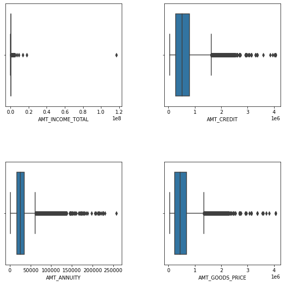

```python
fig,axes =plt.subplots(2,2,figsize=(10,10))
sns.boxplot("AMT_INCOME_TOTAL",data =Client_Data,ax=axes[0,0])
sns.boxplot("AMT_CREDIT",data =Client_Data,ax=axes[0,1])
sns.boxplot("AMT_ANNUITY",data =Client_Data,ax=axes[1,0])
sns.boxplot("AMT_GOODS_PRICE",data =Client_Data,ax=axes[1,1])
fig. tight_layout(pad =8.0)
```

```python
Client_Data[["AMT_INCOME_TOTAL","AMT_CREDIT"]].describe()
```

|  | AMT_INCOME_TOTAL | AMT_CREDIT |
| --- | --- | --- |
| count | 3.051850e+05 | 3.051850e+05 |
| mean | 1.686140e+05 | 5.992816e+05 |
| std | 2.376652e+05 | 4.020170e+05 |
| min | 2.565000e+04 | 4.500000e+04 |
| 25% | 1.125000e+05 | 2.700000e+05 |
| 50% | 1.458000e+05 | 5.147775e+05 |
| 75% | 2.025000e+05 | 8.086500e+05 |
| max | 1.170000e+08 | 4.050000e+06 |

```python
Client_Data.loc[Client_Data["AMT_INCOME_TOTAL"]>6000000,["TARGET","AMT_INCOME_TOTAL","AMT_CREDIT"]].head(10)
```

|  | TARGET | AMT_INCOME_TOTAL | AMT_CREDIT |
| --- | --- | --- | --- |
| 12840 | 1 | 117000000.0 | 562491.0 |
| 77768 | 0 | 9000000.0 | 1431531.0 |
| 131127 | 0 | 6750000.0 | 790830.0 |
| 203693 | 0 | 18000090.0 | 675000.0 |
| 246858 | 0 | 13500000.0 | 1400503.5 |

```python
Client_Data.drop(Client_Data[Client_Data["AMT_INCOME_TOTAL"]>6000000].index,inplace=True)
```

```python
Client_Data.loc[Client_Data["AMT_INCOME_TOTAL"]>6000000,["TARGET","AMT_INCOME_TOTAL","AMT_CREDIT"]].head(10)
```

|  | TARGET | AMT_INCOME_TOTAL | AMT_CREDIT |
| --- | --- | --- | --- |

```python
Client_Data.describe()
```

|  | SK_ID_CURR | TARGET | CNT_CHILDREN | AMT_INCOME_TOTAL | AMT_CREDIT | AMT_ANNUITY | AMT_GOODS_PRICE | Age | DAYS_EMPLOYED | DAYS_ID_PUBLISH | FLAG_MOBIL | FLAG_EMP_PHONE | FLAG_WORK_PHONE | FLAG_CONT_MOBILE | FLAG_EMAIL | CNT_FAM_MEMBERS | REGION_RATING_CLIENT | REGION_RATING_CLIENT_W_CITY | HOUR_APPR_PROCESS_START | REG_CITY_NOT_LIVE_CITY | REG_CITY_NOT_WORK_CITY | LIVE_CITY_NOT_WORK_CITY | OBS_30_CNT_SOCIAL_CIRCLE | DEF_30_CNT_SOCIAL_CIRCLE | OBS_60_CNT_SOCIAL_CIRCLE | DEF_60_CNT_SOCIAL_CIRCLE | DAYS_LAST_PHONE_CHANGE | FLAG_DOCUMENT_2 | FLAG_DOCUMENT_3 | … |
| --- | --- | --- | --- | --- | --- | --- | --- | --- | --- | --- | --- | --- | --- | --- | --- | --- | --- | --- | --- | --- | --- | --- | --- | --- | --- | --- | --- | --- | --- | --- |
| count | 305180.000000 | 305180.000000 | 305180.000000 | 3.051800e+05 | 3.051800e+05 | 305180.000000 | 3.051800e+05 | 305180.000000 | 305180.000000 | 305180.000000 | 305180.0 | 305180.000000 | 305180.000000 | 305180.000000 | 305180.000000 | 305180.000000 | 305180.000000 | 305180.000000 | 305180.000000 | 305180.000000 | 305180.000000 | 305180.000000 | 305180.000000 | 305180.000000 | 305180.000000 | 305180.000000 | 305180.000000 | 305180.000000 | 305180.000000 | … |
| mean | 278164.564955 | 0.080995 | 0.417147 | 1.680786e+05 | 5.992755e+05 | 27135.854142 | 5.382210e+05 | 43.417852 | 17.970827 | 8.199222 | 1.0 | 0.819720 | 0.199695 | 0.998142 | 0.056852 | 2.153119 | 2.053267 | 2.032266 | 12.059365 | 0.078210 | 0.230654 | 0.179723 | 1.421636 | 0.143397 | 1.404709 | 0.100026 | 965.048499 | 0.000043 | 0.712874 | … |
| std | 102784.567591 | 0.272828 | 0.722266 | 9.867711e+04 | 4.020147e+05 | 14473.432700 | 3.689252e+05 | 11.941783 | 25.076377 | 4.131791 | 0.0 | 0.384422 | 0.399772 | 0.043064 | 0.231559 | 0.910632 | 0.508846 | 0.502577 | 3.265782 | 0.268502 | 0.421252 | 0.383958 | 2.400958 | 0.446704 | 2.379842 | 0.362293 | 826.887158 | 0.006527 | 0.452421 | … |
| min | 100002.000000 | 0.000000 | 0.000000 | 2.565000e+04 | 4.500000e+04 | 1615.500000 | 4.050000e+04 | 20.000000 | 0.100000 | 0.100000 | 1.0 | 0.000000 | 0.000000 | 0.000000 | 0.000000 | 1.000000 | 1.000000 | 1.000000 | 0.000000 | 0.000000 | 0.000000 | 0.000000 | 0.000000 | 0.000000 | 0.000000 | 0.000000 | 0.000000 | 0.000000 | 0.000000 | … |
| 25% | 189128.750000 | 0.000000 | 0.000000 | 1.125000e+05 | 2.700000e+05 | 16573.500000 | 2.385000e+05 | 34.000000 | 2.600000 | 4.700000 | 1.0 | 1.000000 | 0.000000 | 1.000000 | 0.000000 | 2.000000 | 2.000000 | 2.000000 | 10.000000 | 0.000000 | 0.000000 | 0.000000 | 0.000000 | 0.000000 | 0.000000 | 0.000000 | 276.000000 | 0.000000 | 0.000000 | … |
| 50% | 278189.500000 | 0.000000 | 0.000000 | 1.455008e+05 | 5.147775e+05 | 24939.000000 | 4.500000e+05 | 43.000000 | 6.100000 | 8.900000 | 1.0 | 1.000000 | 0.000000 | 1.000000 | 0.000000 | 2.000000 | 2.000000 | 2.000000 | 12.000000 | 0.000000 | 0.000000 | 0.000000 | 0.000000 | 0.000000 | 0.000000 | 0.000000 | 760.000000 | 0.000000 | 1.000000 | … |
| 75% | 367120.250000 | 0.000000 | 1.000000 | 2.025000e+05 | 8.086500e+05 | 34614.000000 | 6.795000e+05 | 53.000000 | 15.700000 | 11.800000 | 1.0 | 1.000000 | 0.000000 | 1.000000 | 0.000000 | 3.000000 | 2.000000 | 2.000000 | 14.000000 | 0.000000 | 0.000000 | 0.000000 | 2.000000 | 0.000000 | 2.000000 | 0.000000 | 1572.000000 | 0.000000 | 1.000000 | … |
| max | 456255.000000 | 1.000000 | 19.000000 | 4.500000e+06 | 4.050000e+06 | 258025.500000 | 4.050000e+06 | 69.000000 | 70.000000 | 19.700000 | 1.0 | 1.000000 | 1.000000 | 1.000000 | 1.000000 | 20.000000 | 3.000000 | 3.000000 | 23.000000 | 1.000000 | 1.000000 | 1.000000 | 348.000000 | 34.000000 | 344.000000 | 24.000000 | 4292.000000 | 1.000000 | 1.000000 | … |

# Univariate Analysis

```
Defaulters(1):  24718 , 8.099482272757061 %
Non-Defaulters(0):  280462 , 91.90051772724294 %
```

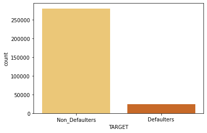

```python
sns.countplot(Client_Data["TARGET"],palette="YlOrBr").set(xticklabels=["Non_Defaulters","Defaulters"])
print("Defaulters(1): ",Client_Data["TARGET"].value_counts()[1],",",(Client_Data["TARGET"].value_counts()[1]/len(Client_Data["TARGET"]))*100,"%")
print("Non-Defaulters(0): ",Client_Data["TARGET"].value_counts()[0],",",(Client_Data["TARGET"].value_counts()[0]/len(Client_Data["TARGET"]))*100,"%")
```

- Only 8% were Defaulters, we have to focus on this category

### Documents Status

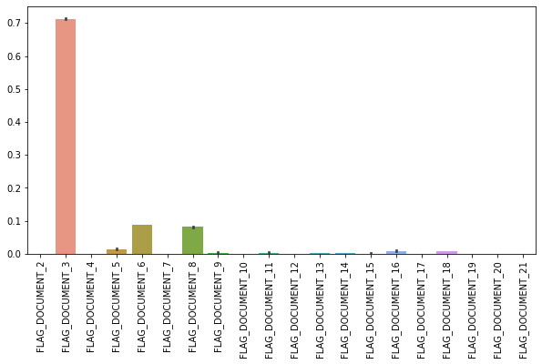

```python
Document_Status =Client_Data[["FLAG_DOCUMENT_2","FLAG_DOCUMENT_3","FLAG_DOCUMENT_4","FLAG_DOCUMENT_5","FLAG_DOCUMENT_6","FLAG_DOCUMENT_7","FLAG_DOCUMENT_8","FLAG_DOCUMENT_9","FLAG_DOCUMENT_10","FLAG_DOCUMENT_11","FLAG_DOCUMENT_12","FLAG_DOCUMENT_13","FLAG_DOCUMENT_14","FLAG_DOCUMENT_15","FLAG_DOCUMENT_16","FLAG_DOCUMENT_17","FLAG_DOCUMENT_18","FLAG_DOCUMENT_19","FLAG_DOCUMENT_20","FLAG_DOCUMENT_21"]]
#Document_Status.head(10)
plt.figure(figsize = (10,5))
sns.barplot(data = Document_Status)
plt.xticks(rotation =90)
```

- Flag_Documents 3,6 and 8 were highly submitted documnets irrespective of Defaulters/Non-Defaulters

### Contact Status

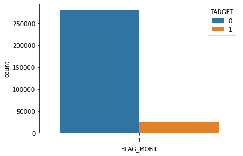

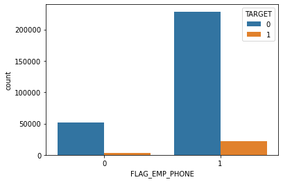

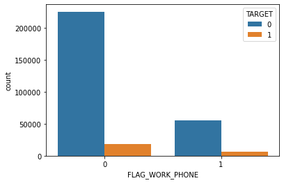

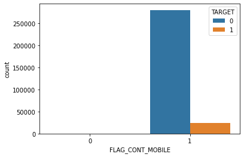

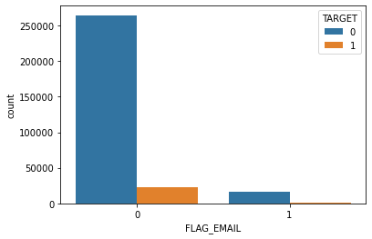

```python
for i in Client_Data[["FLAG_MOBIL","FLAG_EMP_PHONE","FLAG_WORK_PHONE","FLAG_CONT_MOBILE","FLAG_EMAIL"]]:
    sns.countplot(data = Client_Data,x= i, hue="TARGET")
    plt.figure(i)
```

```python
for i in Client_Data[["FLAG_MOBIL","FLAG_EMP_PHONE","FLAG_WORK_PHONE","FLAG_CONT_MOBILE","FLAG_EMAIL" ]]:
    defaulters = Client_Data[(Client_Data[i]==0) & (Client_Data["TARGET"] ==1)]
    Total = len(Client_Data[Client_Data["TARGET"] ==1])
    print(i,":  ",round((len(defaulters)/Total)*100,3))
```

```
FLAG_MOBIL :   0.0
FLAG_EMP_PHONE :   12.036
FLAG_WORK_PHONE :   76.208
FLAG_CONT_MOBILE :   0.182
FLAG_EMAIL :   94.453
```

- 76% home phone data Missing with Defaulters.
- Email Category was higly neglected in all Applications.

### Asset Status

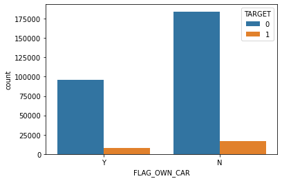

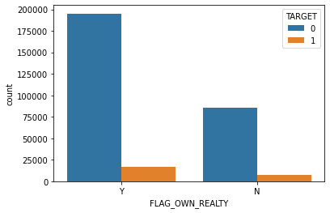

```python
for i in Client_Data[["FLAG_OWN_CAR","FLAG_OWN_REALTY"]]:
    plt.figure(i)
    sns.countplot(data = Client_Data,x= i, hue="TARGET",order=("Y","N"))
```

```python
for i in Client_Data[["FLAG_OWN_CAR","FLAG_OWN_REALTY"]]:
    defaulters1 = Client_Data[(Client_Data[i]=="Y") & (Client_Data["TARGET"] ==1)]
    defaulters2 = Client_Data[(Client_Data[i]=="N") & (Client_Data["TARGET"] ==1)]
    Total = len(Client_Data[Client_Data["TARGET"] ==1])
    print(i,"(H/C)",":  ",round((len(defaulters1)/Total)*100,3))
    print(i,"(NH/NC)",":  ",round((len(defaulters2)/Total)*100,3))
```

```
FLAG_OWN_CAR (H/C) :   30.532
FLAG_OWN_CAR (NH/NC) :   69.468
FLAG_OWN_REALTY (H/C) :   68.452
FLAG_OWN_REALTY (NH/NC) :   31.548
```

- 70% of Defaulters dont have own car but had Own house which is a Risk factor

### Family Details

```python
Fam_Details = Client_Data[["NAME_CONTRACT_TYPE","CODE_GENDER","CNT_FAM_MEMBERS","CNT_CHILDREN","NAME_INCOME_TYPE","NAME_EDUCATION_TYPE","NAME_FAMILY_STATUS","NAME_TYPE_SUITE","NAME_HOUSING_TYPE"]]
```

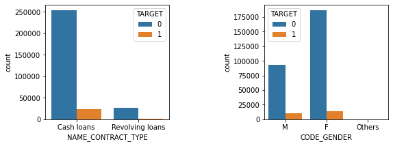

```python
fig,axes =plt.subplots(1,2,figsize=(10,5),)
sns.countplot(data =Client_Data,x="NAME_CONTRACT_TYPE",hue="TARGET",ax=axes[0])
sns.countplot(x="CODE_GENDER",hue="TARGET",data =Client_Data,ax=axes[1])
fig. tight_layout(pad =8.0)
```

```python
for i in Fam_Details["NAME_CONTRACT_TYPE"].unique():
    defaulters1 = Fam_Details[(Fam_Details["NAME_CONTRACT_TYPE"] == i) & (Client_Data["TARGET"] ==1)]
    Total = len(Client_Data[Client_Data["TARGET"] ==1])
    print(i,":  ",(len(defaulters1)/Total)*100)
```

```
Cash loans :   93.7454486608949
Revolving loans :   6.254551339105105
```

- Highest Applicants and Defaulters are Female and of Cash loans
- But when compared to total Male Applicants, the deafulters were quite high in Male

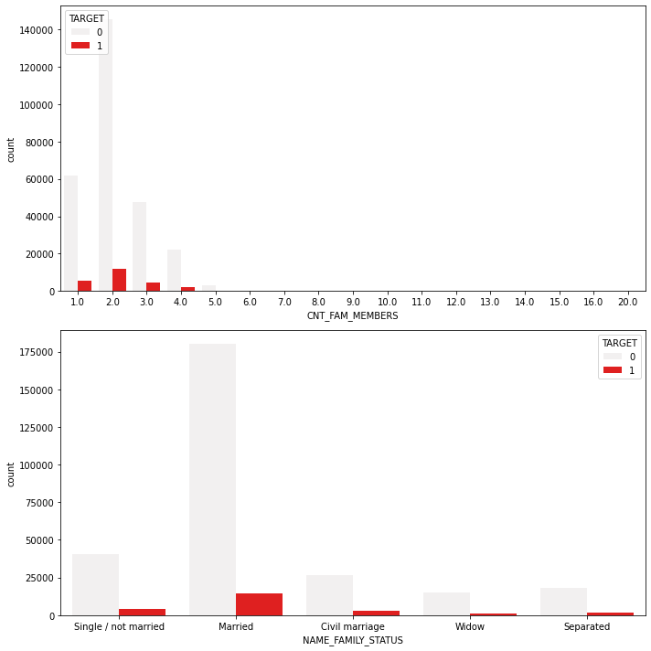

```python
fig,axes =plt.subplots(2,1,figsize=(10,10))
sns.countplot(data =Client_Data,x="CNT_FAM_MEMBERS",hue="TARGET",ax=axes[0],color="red")
sns.countplot(data =Client_Data,x="NAME_FAMILY_STATUS",hue="TARGET",ax=axes[1],color="red")
fig.tight_layout()
```

```python
for i in Fam_Details["NAME_FAMILY_STATUS"].unique():
    defaulters1 = Fam_Details[(Fam_Details["NAME_FAMILY_STATUS"] == i) & (Client_Data["TARGET"] ==1)]
    Total = len(Client_Data[Client_Data["TARGET"] ==1])
    print(i,":  ",round((len(defaulters1)/Total)*100,3))
```

```
Single / not married :   17.967
Married :   59.815
Civil marriage :   11.922
Widow :   3.779
Separated :   6.518
```

```python
for i in Fam_Details["CNT_FAM_MEMBERS"].unique():
    defaulters1 = Fam_Details[(Fam_Details["CNT_FAM_MEMBERS"] == i) & (Client_Data["TARGET"] ==1)]
    Total = len(Client_Data[Client_Data["TARGET"] ==1])
    print(i,":  ",round((len(defaulters1)/Total)*100,3))
```

```
1.0 :   22.87
2.0 :   48.357
3.0 :   18.557
4.0 :   8.609
5.0 :   1.323
6.0 :   0.223
9.0 :   0.0
7.0 :   0.024
8.0 :   0.024
10.0 :   0.004
13.0 :   0.004
14.0 :   0.0
12.0 :   0.0
20.0 :   0.0
15.0 :   0.0
16.0 :   0.0
11.0 :   0.004
```

- Eventhough highest Defaulters lie around Married, but risk factor is high with ~5 - ~10% Single,Civil marriages and Seperated
- Highest Defaulters with Family members less than 5

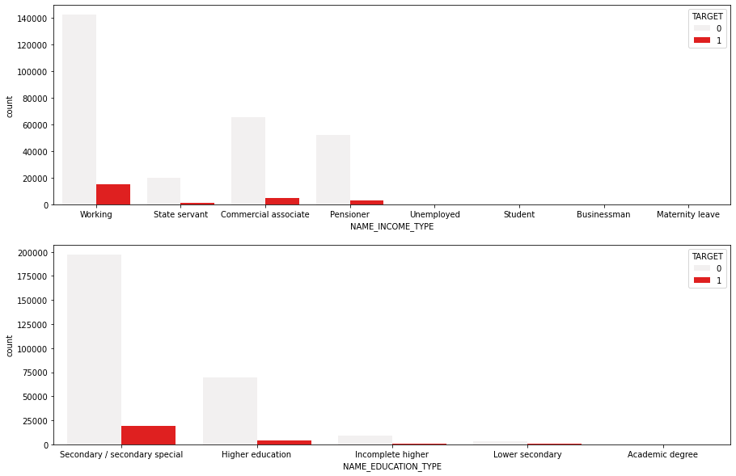

```python
fig,axes =plt.subplots(2,1,figsize=(15,10))
sns.countplot(data =Client_Data,x="NAME_INCOME_TYPE",hue="TARGET",ax=axes[0],color="red")
sns.countplot(data =Client_Data,x="NAME_EDUCATION_TYPE",hue="TARGET",ax=axes[1],color="red")
```

```python
for i in Fam_Details["NAME_EDUCATION_TYPE"].unique():
    defaulters1 = Fam_Details[(Fam_Details["NAME_EDUCATION_TYPE"] == i) & (Client_Data["TARGET"] ==1)]
    Total = len(Client_Data[Client_Data["TARGET"] ==1])
    print(i,":  ",round((len(defaulters1)/Total)*100,3))
```

```
Secondary / secondary special :   78.684
Higher education :   16.118
Incomplete higher :   3.508
Lower secondary :   1.679
Academic degree :   0.012
```

```python
for i in Fam_Details["NAME_INCOME_TYPE"].unique():
    defaulters1 = Fam_Details[(Fam_Details["NAME_INCOME_TYPE"] == i) & (Client_Data["TARGET"] ==1)]
    Total = len(Client_Data[Client_Data["TARGET"] ==1])
    print(i,":  ",round((len(defaulters1)/Total)*100,3))
```

```
Working :   61.372
State servant :   5.021
Commercial associate :   21.567
Pensioner :   11.999
Unemployed :   0.032
Student :   0.0
Businessman :   0.0
Maternity leave :   0.008
```

- Highest Defaulters were Working and Commercial associate, but the risk to be assesed on 11% Pensioner based on their asset value.

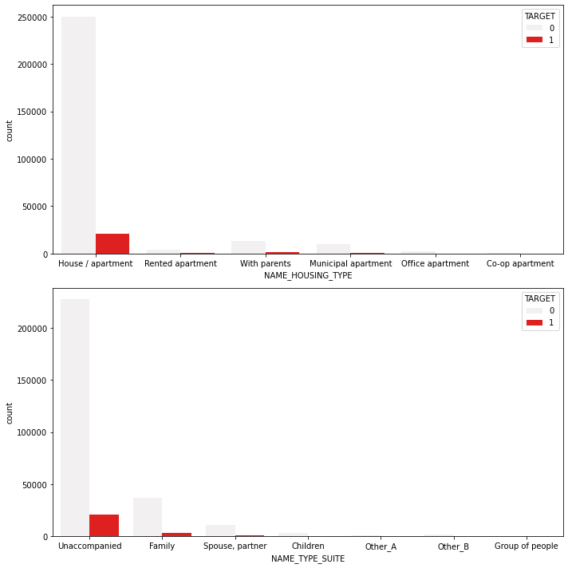

```python
fig,axes =plt.subplots(2,1,figsize=(10,10))
sns.countplot(data =Client_Data,x="NAME_HOUSING_TYPE",hue="TARGET",ax=axes[0],color="red")
sns.countplot(data =Client_Data,x="NAME_TYPE_SUITE",hue="TARGET",ax=axes[1],color="red")
fig.tight_layout()
```

```python
for i in Fam_Details["NAME_HOUSING_TYPE"].unique():
    defaulters1 = Fam_Details[(Fam_Details["NAME_HOUSING_TYPE"] == i) & (Client_Data["TARGET"] ==1)]
    Total = len(Client_Data[Client_Data["TARGET"] ==1])
    print(i,":  ",round((len(defaulters1)/Total)*100,3))
```

```
House / apartment :   85.691
Rented apartment :   2.415
With parents :   7.007
Municipal apartment :   3.843
Office apartment :   0.688
Co-op apartment :   0.356
```

```python
for i in Fam_Details["NAME_TYPE_SUITE"].unique():
    defaulters1 = Fam_Details[(Fam_Details["NAME_TYPE_SUITE"] == i) & (Client_Data["TARGET"] ==1)]
    Total = len(Client_Data[Client_Data["TARGET"] ==1])
    print(i,":  ",round((len(defaulters1)/Total)*100,3))
```

```
Unaccompanied :   82.13
Family :   12.169
Spouse, partner :   3.621
Children :   0.975
Other_A :   0.307
Other_B :   0.704
Group of people :   0.093
```

- 82% Defaulters were Unaccompanied while submiting loan Application, but cannot be considered as primary risk factor
- 2% Defaulters live in Rented Apartments a concern factor.

```python
Client_Data1=Client_Data.copy()
```

```python
Client_Data1["Age"] = pd.cut(x= Client_Data1["Age"],bins = [20,25,30,35,40,45,50,55,60,65,70],labels = ['20-25','25-30','30-35','35-40','40-45','45-50','50-55','55-60','60-65','65-70'])
Client_Data1["DAYS_EMPLOYED"] = pd.cut(x= Client_Data1["DAYS_EMPLOYED"],bins = [0.1,1.0,5.0,10.0,15.0,20.0,30.0,40.0,70.0],labels = ['<1Years','1-5','5-10','10-15','15-20','20-30','30-40','40-70'])
Client_Data1["DAYS_ID_PUBLISH"] = pd.cut(x= Client_Data1["DAYS_ID_PUBLISH"],bins = [0.1,1.0,5.0,10.0,15.0,20.0],labels = ['<1Years','1-5','5-10','10-15','15-20'])
```

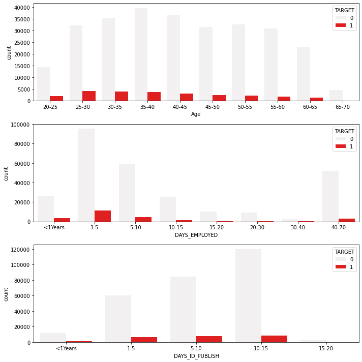

```python
fig,axes =plt.subplots(3,1,figsize=(10,10))
sns.countplot(data =Client_Data1,x="Age",hue="TARGET",ax=axes[0],color="red")
sns.countplot(data =Client_Data1,x="DAYS_EMPLOYED",hue="TARGET",ax=axes[1],color="red")
sns.countplot(data =Client_Data1,x="DAYS_ID_PUBLISH",hue="TARGET",ax=axes[2],color="red")
fig.tight_layout()
```

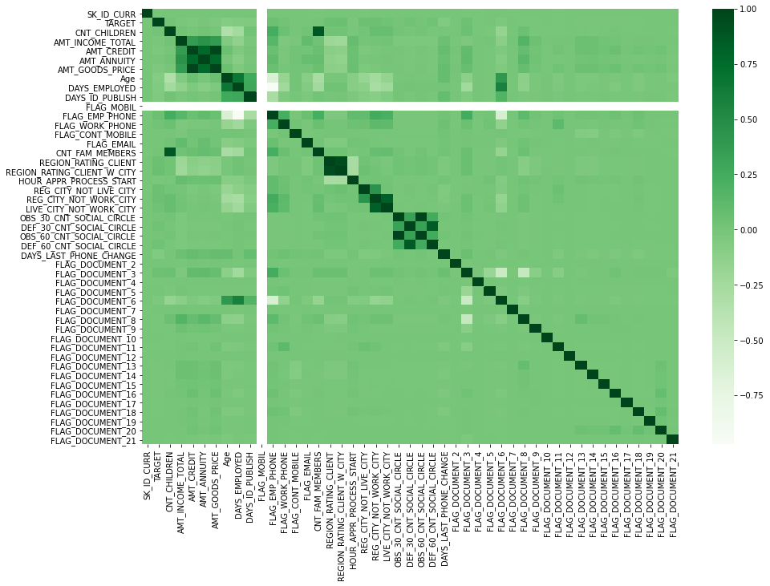

```python
plt.figure(figsize=(15,10))
sns.heatmap(Client_Data.corr(), cmap="Greens")
```

- Amt_Goods Price is highly correlated with Amt_Credit.
- From our Document Status plot, we didnt got much insights, but we could see correlation exists between Age,Days_Employed with Flag document6.

### Bi-Variate Analysis

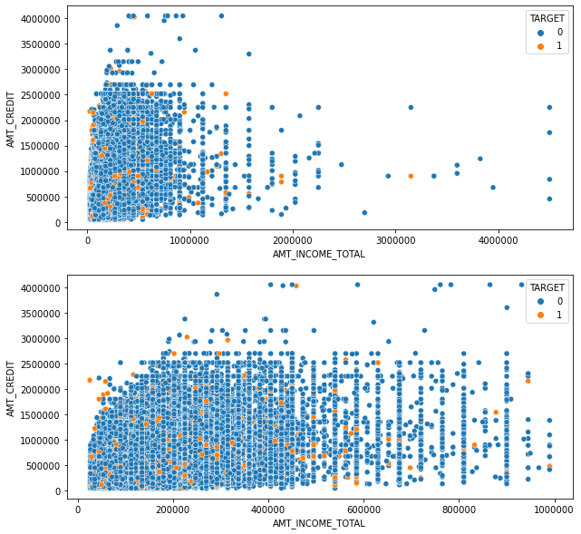

```python
fig,ax =plt.subplots(2,1,figsize=(10,10))
sns.scatterplot(data=Client_Data, x="AMT_INCOME_TOTAL", y="AMT_CREDIT",hue ="TARGET",ax=ax[0])
Inc =Client_Data.loc[Client_Data["AMT_INCOME_TOTAL"]<1000000,["AMT_INCOME_TOTAL","TARGET","AMT_CREDIT"]]
sns.scatterplot(data=Inc, x="AMT_INCOME_TOTAL", y="AMT_CREDIT",hue ="TARGET",ax=ax[1])

for ax in fig.axes:
    plt.sca(ax)
    plt.ticklabel_format(style='plain', axis='both')
```

- Majority of Applicants has Income <1Millions and Credited loan amount is < 2.5 Millions
- More Defaulters fall under Income range of 0.4 Millions

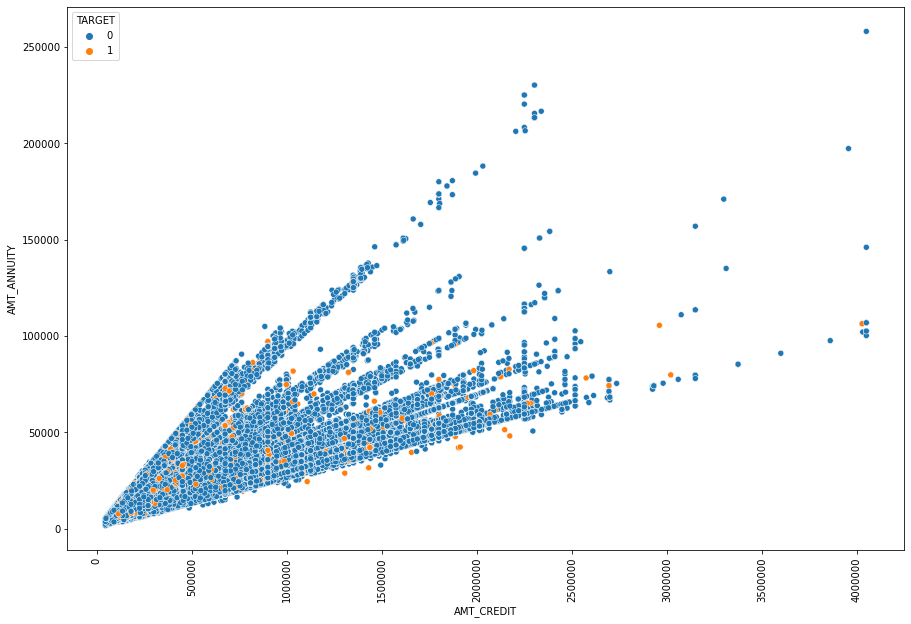

```python
plt.figure(figsize=(15,10),)
sns.scatterplot(data=Client_Data, x="AMT_CREDIT", y="AMT_ANNUITY",hue ="TARGET")
plt.ticklabel_format(style='plain', axis='both')
plt.xticks(rotation =90)
```

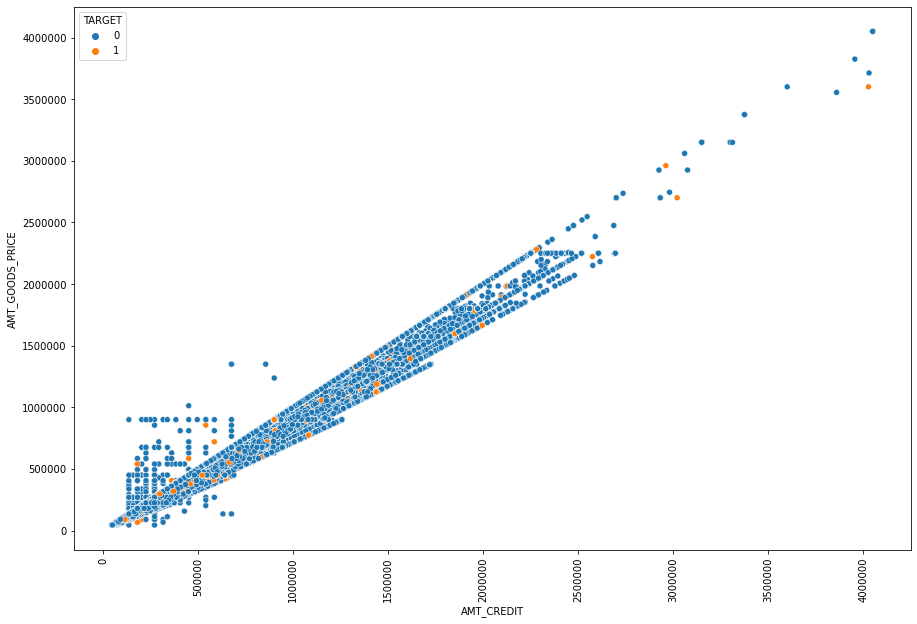

```python
plt.figure(figsize=(15,10),)
sns.scatterplot(data=Client_Data, x="AMT_CREDIT", y="AMT_GOODS_PRICE",hue ="TARGET")
plt.ticklabel_format(style='plain', axis='both')
plt.xticks(rotation =90)
```

## Conclusion:

8% were Defaulters out of 3Lakh Applicants.

Findings:

```python
Client_Data.to_csv("Client_data.csv",index=False)
```